# Methods for Data Science Coursework 1

Juliette Limozin  
CID: 01343907  
Due: 04/11/2019, 5 pm

Let us first import the necessary packages and CSV files:

```python
import pandas as pd
import numpy as np

climbing_stats = pd.read_csv("climbing_statistics.csv",
                             parse_dates=['Date'])
climbing_stats.head()
```

|  | Date | Route | Attempted | Succeeded | Success Percentage |
| --- | --- | --- | --- | --- | --- |
| 0 | 2015-11-27 | Disappointment Cleaver | 2 | 0 | 0.0 |
| 1 | 2015-11-21 | Disappointment Cleaver | 3 | 0 | 0.0 |
| 2 | 2015-10-15 | Disappointment Cleaver | 2 | 0 | 0.0 |
| 3 | 2015-10-13 | Little Tahoma | 8 | 0 | 0.0 |
| 4 | 2015-10-09 | Disappointment Cleaver | 2 | 0 | 0.0 |

```python
r_weather = pd.read_csv("Rainier_Weather.csv",
                       parse_dates=['Date'])
r_weather.head()
```

|  | Date | Battery Voltage AVG | Temperature AVG | Relative Humidity AVG | Wind Speed Daily AVG | Wind Direction AVG | Solar Radiation AVG |
| --- | --- | --- | --- | --- | --- | --- | --- |
| 0 | 2015-12-31 | 13.845000 | 19.062917 | 21.870833 | 21.977792 | 62.325833 | 84.915292 |
| 1 | 2015-12-30 | 13.822917 | 14.631208 | 18.493833 | 3.540542 | 121.505417 | 86.192833 |
| 2 | 2015-12-29 | 13.834583 | 6.614292 | 34.072917 | 0.000000 | 130.291667 | 85.100917 |
| 3 | 2015-12-28 | 13.710417 | 8.687042 | 70.557917 | 0.000000 | 164.683750 | 86.241250 |
| 4 | 2015-12-27 | 13.362500 | 14.140417 | 95.754167 | 0.000000 | 268.479167 | 31.090708 |

Note that I have already converted the dates into datetime objects to simplify plottings for later.

## Task 1: Exploring data

### 1.1 Cleaning data

#### 1.1.1

I created a dataframe that summarises the information required for this question.

```python
# I use groupby() to work with groups of rows that have identical date and route.
#I then sum the 'Attempted'column to get the total attempts for the same date and route
attempts_successes = pd.DataFrame(climbing_stats.groupby(['Date','Route'], group_keys=False).Attempted.sum())

# I create the column 'Succeeded' which is also the sum of successes.
attempts_successes['Succeeded'] = pd.DataFrame(climbing_stats.groupby(['Date','Route'], \
                                                                      group_keys=False).Succeeded.sum())['Succeeded']

# The 'Success percentage', the percentage of successes for the same route and date,
#is computed using 'Attempted' and 'Succeeded'
attempts_successes['Success percentage'] = attempts_successes['Succeeded']/attempts_successes['Attempted']

#The groupby() function makes the columns 'Date' and 'Route' as indexes so I used rest_index() twice to undo that:
attempts_successes.reset_index(level=0, inplace=True)
attempts_successes.reset_index(level=0, inplace=True)

#I drop any inconsistent rows, which are the ones that have higher successes than attempts
attempts_successes.drop(attempts_successes[attempts_successes['Attempted'] \
                                           < attempts_successes['Succeeded']].index, inplace = True)

# Print to check:
attempts_successes.head()
```

|  | Route | Date | Attempted | Succeeded | Success percentage |
| --- | --- | --- | --- | --- | --- |
| 0 | Gibralter Ledges | 2014-01-04 | 3 | 2 | 0.666667 |
| 1 | Disappointment Cleaver | 2014-01-05 | 2 | 0 | 0.000000 |
| 2 | Disappointment Cleaver | 2014-01-06 | 16 | 0 | 0.000000 |
| 3 | Little Tahoma | 2014-01-16 | 2 | 0 | 0.000000 |
| 4 | Gibralter Ledges | 2014-01-18 | 8 | 4 | 0.500000 |

#### 1.1.2

I drop columns from Rainier_weather that do not contain weather informations, so essentially I drop the 'Battery Voltage AVG' column.

```python
r_weather = r_weather.drop(columns = ['Battery Voltage AVG'])
```

#### 1.1.3

I use the merge() function to merge the cleaned dataframes by date:

```python
merged = attempts_successes.merge(r_weather, on='Date')
merged.head()
```

|  | Route | Date | Attempted | Succeeded | Success percentage | Temperature AVG | Relative Humidity AVG | Wind Speed Daily AVG | Wind Direction AVG | Solar Radiation AVG |
| --- | --- | --- | --- | --- | --- | --- | --- | --- | --- | --- |
| 0 | Disappointment Cleaver | 2014-09-23 | 11 | 0 | 0.000000 | 32.857333 | 100.000000 | 65.110667 | 254.273333 | 16.593800 |
| 1 | Disappointment Cleaver | 2014-09-24 | 12 | 0 | 0.000000 | 29.702917 | 100.000000 | 45.915000 | 278.054167 | 37.873708 |
| 2 | Disappointment Cleaver | 2014-09-25 | 14 | 8 | 0.571429 | 26.823750 | 99.854167 | 3.166208 | 278.604167 | 142.698917 |
| 3 | Disappointment Cleaver | 2014-09-26 | 41 | 19 | 0.463415 | 28.238333 | 100.000000 | 0.897625 | 259.645833 | 114.400833 |
| 4 | Disappointment Cleaver | 2014-09-27 | 44 | 25 | 0.568182 | 33.318750 | 60.200417 | 7.140917 | 116.294583 | 227.597125 |

### 1.2 Visualising data

#### 1.2.1

Note that at the beginning of the coursework, I directly imported the csv files with dates already converted into datetime objects so the date column in our data frame 'merged' is already a linear time variable.

```python
import matplotlib.pyplot as plt

#Create a shortcut for the Date column to simplify things
x = merged['Date']
```

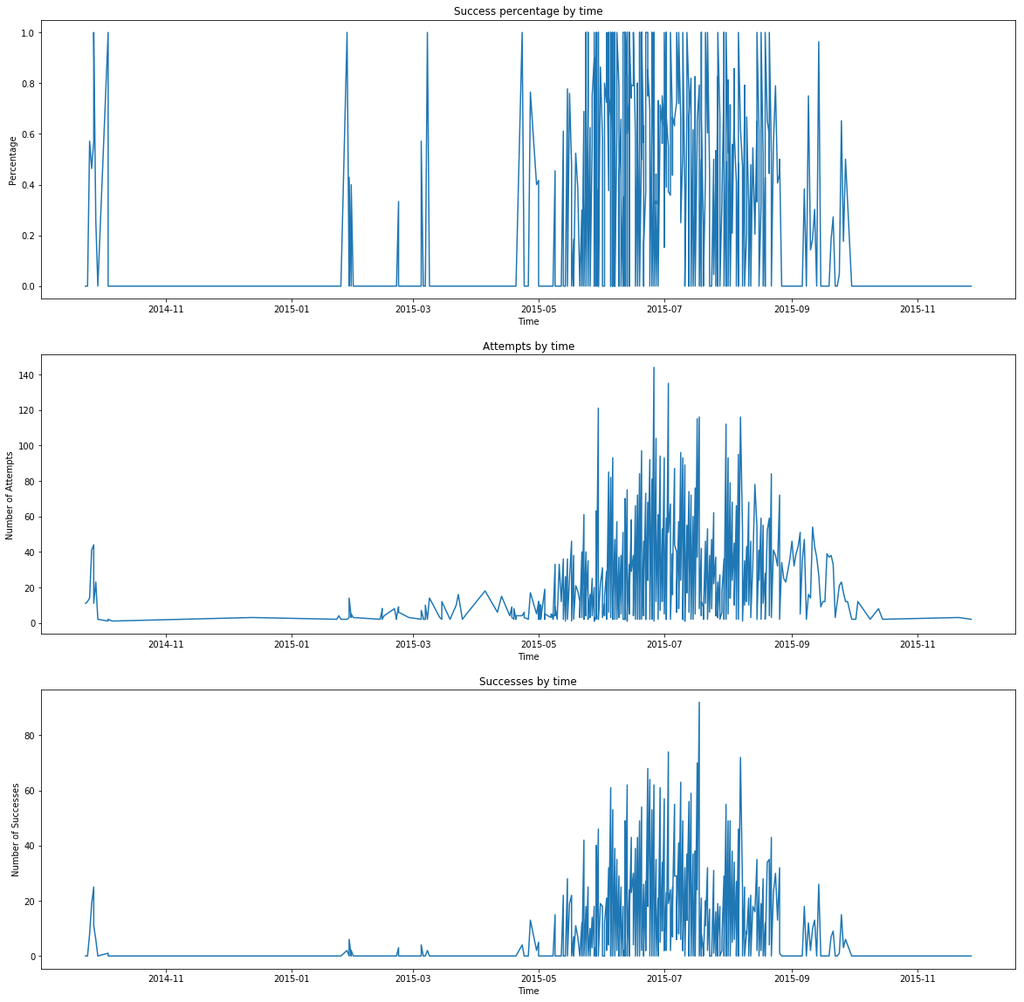

```python
fig, (ax1, ax2, ax3) = plt.subplots(3, 1, figsize = (20, 20))

ax1.plot(x, merged['Success percentage'])
ax1.set_title('Success percentage by time')
ax1.set(xlabel='Time', ylabel='Percentage')

ax2.plot(x, merged['Attempted'])
ax2.set_title('Attempts by time')
ax2.set(xlabel='Time', ylabel='Number of Attempts')

ax3.plot(x, merged['Succeeded'])
ax3.set_title('Successes by time')
ax3.set(xlabel='Time', ylabel='Number of Successes')

plt.show()
```

#### 1.2.2

I use the twinx() function to have one plot with 2 y-axes (source: https://matplotlib.org/gallery/api/two_scales.html)

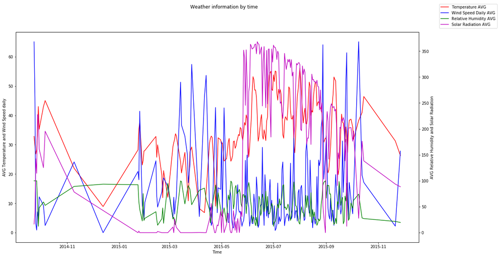

```python
fig, ax1 = plt.subplots(figsize = (20,10))

line_labels = ["Temperature AVG", "Wind Speed Daily AVG", "Relative Humidity AVG", "Solar Radiation AVG"]

ax1.set_xlabel('Time')
ax1.set_ylabel('AVG Temperature and Wind Speed daily')
l1 = ax1.plot(x, merged['Temperature AVG'], c = 'r')
l2 = ax1.plot(x, merged['Wind Speed Daily AVG'], c = 'b')
ax1.tick_params(axis='y')


ax2 = ax1.twinx()

ax2.set_ylabel('AVG Relative Humidity and Solar Radiation')
l3 = ax2.plot(x, merged['Relative Humidity AVG'], c= 'g')
l4 = ax2.plot(x, merged['Solar Radiation AVG'], c='m')
ax2.tick_params(axis='y')

fig.suptitle('Weather information by time')
fig.legend([l1, l2, l3, l4], labels=line_labels,  loc="upper right", borderaxespad=1)

plt.subplots_adjust(right=0.85)
plt.show()
```

#### 1.2.3

This time I use twiny() to have one y axis and 2 x axes:

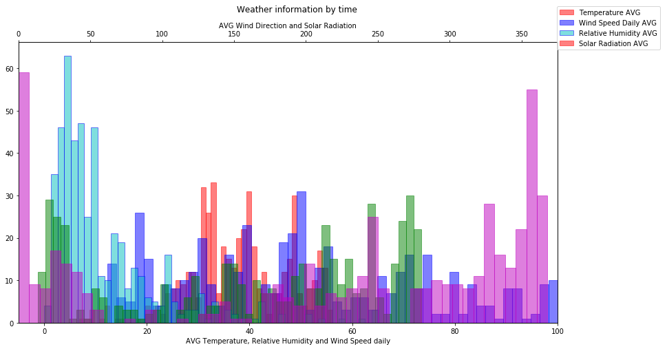

```python
fig, ax1 = plt.subplots(figsize = (15,7.5))

ax1.set_xlabel('AVG Temperature, Relative Humidity and Wind Speed daily')
l1 = ax1.hist(merged['Temperature AVG'], bins = 50, edgecolor= 'r', alpha=0.5, color='r')
l2 = ax1.hist(merged['Relative Humidity AVG'], bins = 50, edgecolor= 'b', alpha=0.5, color= 'b')
l3 = ax1.hist(merged['Wind Speed Daily AVG'], bins = 50, edgecolor= 'b', alpha=0.5, color= 'c')
ax1.set_xlim([-5,100])
ax1.tick_params(axis='x')

ax2 = ax1.twiny()

ax2.set_xlabel('AVG Wind Direction and Solar Radiation')
l4 = ax2.hist(merged['Wind Direction AVG'], bins = 50, edgecolor='g', alpha=0.5, color= 'g')
l5 = ax2.hist(merged['Solar Radiation AVG'], bins = 50, edgecolor= 'm', alpha=0.5, color='m')
ax2.set_xlim([0,375])
ax2.tick_params(axis='x')

fig.suptitle('Weather information by time')
fig.legend([l1, l2, l3, l4, l5], labels=line_labels,  loc="upper right", borderaxespad=1)

plt.subplots_adjust(right=0.85)
plt.show()
```

### 1.3 Visualising relationships between descriptors

I first create a table with only the weather information to facilitate things afterwards in the function.

```python
df = merged[['Temperature AVG', 'Relative Humidity AVG', 'Wind Speed Daily AVG','Wind Direction AVG', 'Solar Radiation AVG']]

#Sense-checking
df.head()
```

|  | Temperature AVG | Relative Humidity AVG | Wind Speed Daily AVG | Wind Direction AVG | Solar Radiation AVG |
| --- | --- | --- | --- | --- | --- |
| 0 | 32.857333 | 100.000000 | 65.110667 | 254.273333 | 16.593800 |
| 1 | 29.702917 | 100.000000 | 45.915000 | 278.054167 | 37.873708 |
| 2 | 26.823750 | 99.854167 | 3.166208 | 278.604167 | 142.698917 |
| 3 | 28.238333 | 100.000000 | 0.897625 | 259.645833 | 114.400833 |
| 4 | 33.318750 | 60.200417 | 7.140917 | 116.294583 | 227.597125 |

Next, I define the function:

```python
def scatter():
    labels = ['Temperature AVG', 'Relative Humidity AVG', 'Wind Speed Daily AVG','Wind Direction AVG', 'Solar Radiation AVG']
    fig, axs = plt.subplots(5, 5, figsize=(20,20))
    i = 0
    for i in range(0,5): #by creating two for loops of i and j,
        #I basically treat the subplots as a 5x5 matrix for which I define each i,j element
        j = 0
        for j in range(0,5):
            axs[i,j].scatter(df.iloc[:,i], df.iloc[:,j])
            axs[i,j].set_xlabel(labels[i])
            axs[i,j].set_ylabel(labels[j])
    plt.show()
    return
```

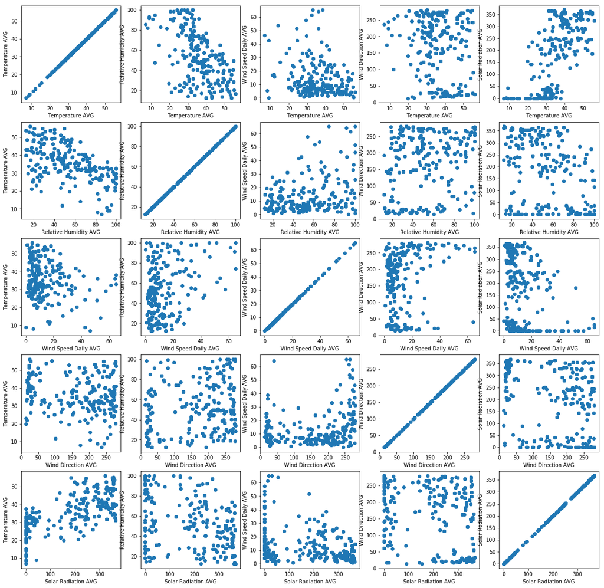

```python
scatter()
```

From these scatter plots, it might be worth observing that Solar Radiation seems to be a good predictor for Temperature, similary with Relative Humidity for Temperetature.

### 1.4 Splitting the data into training and validation sets

We want to split the merged data into two data sets, training which contains 80% of the merged rows and validation which contains the remaining 20%. First I want to know what represent 80% and 20% of the number of rows from merged:

```python
merged.shape
```

```
(481, 10)
```

```python
0.8*481
```

```
384.8
```

```python
0.2*481
```

```
96.2
```

```python
n = 385
m = 96
import random as rd
```

Next, I define my splitting function.

```python
def split(l, n, data):
    x = np.array(rd.sample(range(0,l), n)) #I randomly select 80% of row length ranging from 0 to total row length
    training = data.iloc[x,:] #i select those 80% from the data set
    validation = data.drop(data.iloc[x,:].index) #I define the validation data set as the data set,
    #but any rows from the training set being dropped to obtain the remaining 20% of rows.
    return training, validation
```

```python
training, validation = split(l = 481, n = 385, data = merged)
```

```python
training.shape
```

```
(385, 10)
```

```python
validation.shape
```

```
(96, 10)
```

## Task 2: Compare regression and classification algorithms

### 2.1 Regression

#### 2.1.1 Linear regression

For this task, we start off by importing the LinearRegression function from sklearn:

```python
from sklearn.linear_model import LinearRegression
from sklearn import metrics
```

Then we determine the table of predictors X and the vector of output y, each from the training set and the validation sets

```python
X_train = training[['Temperature AVG', 'Relative Humidity AVG', 'Wind Speed Daily AVG', 'Solar Radiation AVG']]
y_train = training['Success percentage']
X_valid = validation[['Temperature AVG', 'Relative Humidity AVG', 'Wind Speed Daily AVG', 'Solar Radiation AVG']]
y_valid = validation['Success percentage']
```

Then we create the regression model using LinearRegression() and train it with the training data.

```python
regressor = LinearRegression()
regressor.fit(X_train, y_train)
```

```
LinearRegression(copy_X=True, fit_intercept=True, n_jobs=1, normalize=False)
```

Here is how we obtain the parameters (here referred to as coef_ in our regressor table) of the model from the training set:

```python
coeff_df = pd.DataFrame(regressor.coef_, X_train.columns, columns=['Parameters'])
coeff_df
```

|  | Parameters |
| --- | --- |
| Temperature AVG | 0.000240 |
| Relative Humidity AVG | 0.000533 |
| Wind Speed Daily AVG | -0.001596 |
| Solar Radiation AVG | 0.001387 |

The way to read this table is that in our linear regression model $y = b_1x_1 +b_2x_2 + b_3x_3 + b_4x_4$ ($x_i$ being our four predictors), the numbers in the column 'Parameters' are $b_1, \space b_2, \space b_3, \space b_4$ respectively.

Now, the in-sample error from the training set is the MSE between the actual and predicted 'Success percentage', y_train and y_pred_train respectively. First we calculate y_pred_train:

```python
y_pred_train = regressor.predict(X_train)
```

Next we define the in-sample error:

```python
print('In-Sample Error:', metrics.mean_squared_error(y_train, y_pred_train))
```

```
In-Sample Error: 0.10568411657966928
```

We now apply the model to the validation data set. To do so, we use the predictors vector X_valid, from the validation set, in the fuction regressor_predict. Here is 'Success percentage'predicted from the validation dataset:

```python
y_pred_valid = regressor.predict(X_valid)
```

```python
print('Out-of-sample error:', metrics.mean_squared_error(y_valid, y_pred_valid))
```

```
Out-of-sample error: 0.13857854568594982
```

The out-of-sample error is bigger than the in-sample error with the training and validation data sets that I randomly generated above (I am pointing this out as depending on both data sets, when running the code this might not be true).

Now let's test the model on the out-of-sample data 'test_set'. First we read the data:

```python
test_set=pd.read_csv("test_set.csv",
                             parse_dates=['Date'])
test_set
```

|  | Date | Temperature AVG | Relative Humidity AVG | Wind Speed Daily AVG | Solar Radiation AVG |
| --- | --- | --- | --- | --- | --- |
| 0 | 2018-12-31 | 24.062910 | 58.87083 | 17.977790 | 121.91529 |
| 1 | 2018-12-30 | 44.631200 | 53.49383 | 13.540541 | 191.19283 |
| 2 | 2018-12-29 | 22.614291 | 60.07291 | 10.451290 | 157.10091 |
| 3 | 2018-12-28 | 31.687041 | 70.55791 | 9.876980 | 176.24120 |

Next, we define the table of predictors just as before:

```python
X_test = test_set[['Temperature AVG', 'Relative Humidity AVG', 'Wind Speed Daily AVG', 'Solar Radiation AVG']]
```

Then as before we apply regressor.predict(), this time on X_test. We obtain the following prediction:

```python
y_pred_test = regressor.predict(X_test)
y_pred_test
```

```
array([0.22324263, 0.32847436, 0.28434443, 0.3195751 ])
```

#### 2.1.2 Ridge regression

For this task we follow similar procedures as with the linear regression, this time using the Ridge function from sklearn.

```python
from sklearn.linear_model import RidgeCV
from sklearn.linear_model import Ridge
```

In order to find the optimal penalty parameter $\lambda$ of our Ridge model, we do what is called a k-fold cross validation using the function RidgeCV. This methods tests different values of $\lambda$ and finds the optimal value based on the value of the MSE. In this case the value $\alpha$ refers to our $\lambda$.

```python
alphas = 10**np.linspace(10,-2,100)*0.5 # we set an array of different possibilities of alpha
ridgecv = RidgeCV(alphas = alphas, scoring = 'neg_mean_squared_error', normalize = True) #a cross validation is run on these alphas
ridgecv.fit(X_train, y_train) #we fit the model with the training data
ridgecv.alpha_
```

```
0.026683496156031508
```

This is the optimal value of $\lambda$.  
Now that we know this we can start doing the tasks similar to the linear regression:

```python
ridge = Ridge(alpha = ridgecv.alpha_, normalize = True)
ridge.fit(X_train, y_train) # we fit the data with the training data

coeff_r = pd.DataFrame(ridge.coef_, X_train.columns, columns=['Parameters'])
coeff_r
```

|  | Parameters |
| --- | --- |
| Temperature AVG | 0.000735 |
| Relative Humidity AVG | 0.000511 |
| Wind Speed Daily AVG | -0.001665 |
| Solar Radiation AVG | 0.001325 |

These are the parameters of the model from the training data set.  
The in-sample error is:

```python
y_pred_train_r = ridge.predict(X_train)
print('In-Sample Error:', metrics.mean_squared_error(y_train, y_pred_train_r))
```

```
In-Sample Error: 0.1057233582803679
```

We know apply our Ridge regression model to our validation data set and obtain the out-of-sample error:

```python
y_pred_valid_r = ridge.predict(X_valid)
print('Out-of-Sample Error:', metrics.mean_squared_error(y_valid, y_pred_valid_r))
```

```
Out-of-Sample Error: 0.13801488890345617
```

Now we test our model on the out-of-sample data 'test_set' which we downloaded earlier and obtain this prediction:

```python
y_pred_test_r = ridge.predict(X_test)
y_pred_test_r
```

```
array([0.22180198, 0.33336211, 0.28050431, 0.31885214])
```

#### 2.1.3 Discussion

We want to compare the performance of the Linear and Ridge regression models. Let us look at the coefficient of determination and MSE from the validation data for Linear and Ridge regression. Ideally they will be close to 1 and 0 respectively.

```python
print('R^2 for Linear regression',regressor.score(X_valid,y_valid))
print('MSE for Linear regression', metrics.mean_squared_error(y_valid, y_pred_valid))
print('R^2 for Ridge regression', ridge.score(X_valid,y_valid))
print('MSE for Ridge regression', metrics.mean_squared_error(y_valid, y_pred_valid_r))
```

```
R^2 for Linear regression 0.048369390148390146
MSE for Linear regression 0.13857854568594982
R^2 for Ridge regression 0.052240069011531
MSE for Ridge regression 0.13801488890345617
```

We can observe that the Ridge regression model gives a lower MSE and higher coefficient of determination $R^2$, therefore it is a better model than the Linear regression model (at least for the randomly generated traning amd validation data sets I obtained while running this code -- results may alter due to randomness of splitting function).

The difference in these results comes from the penalty paramter $\lambda$. Had $\lambda$ being equal to zero, the loss function would just become the ordinary least squares loss function which is the one we use for linear regression.

However, when we actually look at the scatter plot bellow which shows the error against the predicted 'Success percentage' from the validation data, we see that both regression models predict very similar values.

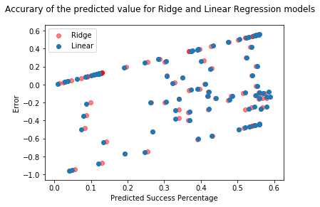

```python
fig, ax = plt.subplots()
ax.scatter(y_pred_valid_r, y_pred_valid_r -y_valid, alpha = 0.5, c= 'r', label = 'Ridge')
ax.scatter(y_pred_valid, y_pred_valid - y_valid, label = 'Linear')
ax.set_xlabel('Predicted Success Percentage')
ax.set_ylabel('Error')
fig.suptitle('Accurary of the predicted value for Ridge and Linear Regression models')
leg = ax.legend();
```

### 2.2 Classification

#### 2.2.1. Preparation of the data as categorical variables

To do this task I first need to convert the 'Succeeded' column's elements as lists of ones and zeros, the number of ones being the number of successes and the number of zeros being the number of unsuccessful attempts. But in order to do so, I first need to convert both 'Attempted' and 'Succeeded' as object types, otherwise I won't be able to define their elememts as lists.

```python
merged.Attempted = merged.Attempted.astype(object)
merged.Succeeded = merged.Succeeded.astype(object)
```

Next, I define a new vector 'Successes' as the vector of lists of ones and zeros as required.

```python
Successes = pd.DataFrame(np.zeros((481,1))).astype(object)
for i in range(0,481):
    Successes.iloc[i,0] = [1]*merged.iloc[i,3] + [0]*(merged.iloc[i,2]-merged.iloc[i,3])
    #unsuccessful attempts = attemots - successes
```

Then I define 'classification', our required data, as the merged data without 'Attempted' and where 'Succeeded' gets replaced as 'Successes so that each of its elements are lists. I then use the explode function to unfold the data according to those lists, hence getting 'Succeeded' as a binary outcome.

```python
df = merged.drop(columns = ['Attempted'])
df['Succeeded'] = Successes
classification = df.explode('Succeeded')
```

#### 2.2.2 Logistic Regression

We begin this task by defining new training and validation data sets from 'classification', using the splitting function I created for Task 1.4. First we need to determine the total number of rows in 'classification' and 80% of that number.

```python
classification.shape
```

```
(10071, 9)
```

```python
0.8*10071
```

```
8056.8
```

So we pick 8057 as the number of 80% of rows. We apply my function split:

```python
training_log, validation_log = split(l = 10071, n = 8057, data = classification)
training_log.head()
```

|  | Route | Date | Succeeded | Success percentage | Temperature AVG | Relative Humidity AVG | Wind Speed Daily AVG | Wind Direction AVG | Solar Radiation AVG |
| --- | --- | --- | --- | --- | --- | --- | --- | --- | --- |
| 298 | Disappointment Cleaver | 2015-07-03 | 0 | 0.548148 | 55.137500 | 20.559417 | 0.753458 | 90.534583 | 357.341167 |
| 409 | Disappointment Cleaver | 2015-08-12 | 1 | 0.478261 | 51.375833 | 46.140417 | 6.673708 | 171.633375 | 208.670500 |
| 357 | Emmons-Winthrop | 2015-07-23 | 0 | 0.000000 | 38.756667 | 43.627917 | 5.683125 | 18.718750 | 301.844042 |
| 56 | Disappointment Cleaver | 2015-04-18 | 0 | 0.000000 | 32.194583 | 18.879167 | 8.654292 | 214.381333 | 34.683958 |
| 461 | Disappointment Cleaver | 2015-09-18 | 0 | 0.000000 | 34.733750 | 52.701667 | 6.354375 | 30.358750 | 200.940625 |

```python
training_log.shape #sense-checking
```

```
(8057, 9)
```

Next, we create and train a logistic regression classifier using the function LogisticRegression from sk-learn:

```python
from sklearn.linear_model import LogisticRegression

X_train = training_log[['Temperature AVG', 'Relative Humidity AVG', 'Wind Speed Daily AVG', 'Solar Radiation AVG']]
y_train = training_log['Succeeded']
y_train = y_train.astype('int') #this is so that when I fit the data, it recognises the binary Successes as categorical.
X_valid = validation_log[['Temperature AVG', 'Relative Humidity AVG', 'Wind Speed Daily AVG', 'Solar Radiation AVG']]
y_valid = validation_log['Succeeded']
y_valid = y_valid.astype('int')


logreg = LogisticRegression(solver='lbfgs', multi_class='multinomial', C=1000)
logreg.fit(X_train, y_train)
```

```
LogisticRegression(C=1000, class_weight=None, dual=False, fit_intercept=True,
          intercept_scaling=1, max_iter=100, multi_class='multinomial',
          n_jobs=1, penalty='l2', random_state=None, solver='lbfgs',
          tol=0.0001, verbose=0, warm_start=False)
```

Next we estimate the probability to successfully summit on the validation data:

```python
y_proba = logreg.predict_proba(X_valid)
y_proba
```

```
array([[0.4612965 , 0.5387035 ],
       [0.4612965 , 0.5387035 ],
       [0.49401091, 0.50598909],
       [0.49401091, 0.50598909],
       [0.53475398, 0.46524602]])
```

Now let us compare the errors in the training and validation data:

```python
y_pred_train = logreg.predict(X_train)
y_pred_valid = logreg.predict(X_valid)

print('Training set MSE:', metrics.mean_squared_error(y_train, y_pred_train))
print('Validation set MSE:', metrics.mean_squared_error(y_valid, y_pred_valid))
print('R^2 on training:', logreg.score(X_train, y_train))
print('R^2 on validation:', logreg.score(X_valid, y_valid))
```

```
Training set MSE: 0.3935708079930495
Validation set MSE: 0.0
R^2 on training: 0.6064291920069504
R^2 on validation: 1.0
```

As we can see, the validation data has a lower MSE and higher coefficient of determination than those of the validation data, so the prediction is better from the validation data set.

#### 2.2.3. Naive Bayes

For this task we do the exact same procedurs as the previous task, but this time using a Naive Bayes classifier. For that we use GaussianNB from sklearn.

```python
from sklearn.naive_bayes import GaussianNB

#Create Naive Bayes classifier
gnb = GaussianNB()

# Train the classifier
gnb.fit(X_train, y_train)

#Probability of summitting on validation data
y_proba = logreg.predict_proba(X_valid)
y_proba
```

```
array([[0.4612965 , 0.5387035 ],
       [0.4612965 , 0.5387035 ],
       [0.49401091, 0.50598909],
       [0.49401091, 0.50598909],
       [0.53475398, 0.46524602]])
```

```python
y_pred_train = logreg.predict(X_train)
y_pred_valid = logreg.predict(X_valid)

print('Training set MSE:', metrics.mean_squared_error(y_train, y_pred_train))
print('Validation set MSE:', metrics.mean_squared_error(y_valid, y_pred_valid))
print('R^2 on training:', logreg.score(X_train, y_train))
print('R^2 on validation:', logreg.score(X_valid, y_valid))
```

```
Training set MSE: 0.3935708079930495
Validation set MSE: 0.0
R^2 on training: 0.6064291920069504
R^2 on validation: 1.0
```